# How to choose words to do things with

Dan Hicks

After extracting text from the documents in our corpus, we typically want to work with a small subset of tokens (text units). Extremely common terms, like “it” and “she,” don’t carry much information; and similarly with misspelled words or OCR errors. Identifying the subset of tokens to use in further analysis is called *vocabulary selection*. This document will discuss the problems with the widely-used TF-IDF method for vocabulary selection, then present my information-theoretic alternative.

# Setup

We’ll use a small part of the combined race science corpus, with 50 articles from each of the 5 journals.

```r
library(tidyverse)
theme_set(theme_bw())
library(tidytext)

library(arrow)
library(here)

data_dir = here('data')
```

```r
meta_ar = open_dataset(here(data_dir, '01_metadata'))

set.seed(2022-02-14)
subset_meta = meta_ar |>
    group_by(container.title) |>
    collect() |>
    slice_sample(n = 50)

count(subset_meta, container.title)
```

```
## # A tibble: 5 × 2
## # Groups:   container.title [5]
##   container.title                   n
##   <chr>                         <int>
## 1 Behavior Genetics                50
## 2 Behavioral and Brain Sciences    50
## 3 Intelligence                     50
## 4 Mankind Quarterly                50
## 5 Psychological Reports            50
```

```r
subset_phr = open_dataset(here(data_dir, '00_phrases')) |>
    filter(article_id %in% subset_meta$article_id) |>
    collect()
```

```r
subset_meta
```

```
## # A tibble: 250 × 6
## # Groups:   container.title [5]
##    article_id              title              volume issue container.title  year
##    <chr>                   <chr>              <chr>  <chr> <chr>           <int>
##  1 10.1007/bf01065562      Social aggregatio… 20     3     Behavior Genet…  1990
##  2 10.1007/bf01065638      Bias in the estim… 12     4     Behavior Genet…  1982
##  3 10.1023/a:1017357211509 <NA>               31     3     Behavior Genet…  2001
##  4 10.1007/bf01065824      Spouse similarity… 11     1     Behavior Genet…  1981
##  5 10.1007/bf01065885      Factor and simple… 19     1     Behavior Genet…  1989
##  6 10.1007/bf01076179      Genetics of a non… 24     5     Behavior Genet…  1994
##  7 10.1007/bf01071744      Enzyme polymorphi… 13     1     Behavior Genet…  1983
##  8 10.1023/a:1025635913927 <NA>               27     4     Behavior Genet…  1997
##  9 10.1023/a:1002748521117 <NA>               30     5     Behavior Genet…  2000
## 10 10.1007/bf01067942      ?Estimating? heri… 8      5     Behavior Genet…  1978
## # … with 240 more rows
```

```r
subset_phr
```

```
## # A tibble: 454,467 × 5
##    article_id phrase                    n prefix  year
##    <chr>      <chr>                 <int> <chr>  <int>
##  1 1960-1-02  they                     11 MQ      1960
##  2 1960-1-02  who                       8 MQ      1960
##  3 1960-1-02  it                        7 MQ      1960
##  4 1960-1-02  australian_aborigines     6 MQ      1960
##  5 1960-1-02  race                      6 MQ      1960
##  6 1960-1-02  world                     6 MQ      1960
##  7 1960-1-02  study                     5 MQ      1960
##  8 1960-1-02  he                        4 MQ      1960
##  9 1960-1-02  new_guinea                4 MQ      1960
## 10 1960-1-02  problems                  4 MQ      1960
## # … with 454,457 more rows
```

# TF-IDF

TF-IDF stands for *token frequency*-*inverse document frequency*. Token frequency is the relative occurrence of the given token in the given document; inverse document frequency is the log ratio of documents in the corpus to documents that contain the token. TF-IDF is the product of these two. TF-IDF is widely used for vocabulary selection in text mining, and [has a one-liner in the `tidytext` package](https://www.tidytextmining.com/tfidf.html).

```r
bind_tf_idf(subset_phr, phrase, article_id, n) |>
    arrange(desc(tf_idf))
```

```
## # A tibble: 454,467 × 8
##    article_id                    phrase       n prefix  year     tf   idf tf_idf
##    <chr>                         <chr>    <int> <chr>  <int>  <dbl> <dbl>  <dbl>
##  1 10.1023/a:1017357211509       john_k_…     2 10.10…    NA 0.0667  5.52  0.368
##  2 10.1017/s0140525x00014254     univ       121 10.10…    NA 0.0859  3.73  0.320
##  3 10.1016/s0160-2896(05)00080-2 elsevie…     3 10.10…    NA 0.0556  5.52  0.307
##  4 10.1016/s0160-2896(05)00080-2 reviewe…     4 10.10…    NA 0.0741  3.58  0.265
##  5 10.2466/pr0.1994.75.1.602     12_regr…     4 10.24…    NA 0.0460  5.52  0.254
##  6 10.2466/pr0.1968.23.2.482     shock_c…     4 10.24…    NA 0.0460  5.52  0.254
##  7 10.2466/pr0.1980.46.3.830     biorhyt…     4 10.24…    NA 0.0404  5.52  0.223
##  8 10.2466/pr0.1980.46.3.830     full_mo…     4 10.24…    NA 0.0404  5.52  0.223
##  9 10.2466/pr0.101.2.519-524     war         57 10.24…    NA 0.0788  2.81  0.222
## 10 10.2466/pr0.1964.14.1.103     hypnoti…    12 10.24…    NA 0.0436  4.83  0.211
## # … with 454,457 more rows
```

This example demonstrates two problems with TF-IDF. First, the TF-IDF value is associated with a token *in a document*, not a token across the entire corpus. After calculating TF-IDF scores, a common next step is to keep the top $n$ tokens for each document. Suppose a token $t$ appears in the top $n$ tokens for document 1, and as the $n+1$th token in documents $2, 3, \ldots, k$. Token $t$ would be eliminated in the other documents, as though it never occurred in them at all. So $t$ would be in the analysis vocabulary — but only for document 1. This creates a weird discretization, and it’s not hard to imagine that it might lead to artifacts.

The second problem is that, when taken across the entire corpus, TF-IDF favors rare terms from short documents. Here’s the entire text of [`10.1023/a:1017357211509`](https://link.springer.com/content/pdf/10.1023/A:1017357211509.pdf), which has the top-scoring token according to TF-IDF, `john_k_hewitt`:

> The editors of Behavior Genetics are pleased to announce that John K. Hewitt, University of Colorado, Boulder, assumed the position of Executive Editor of the journal in July 2001. He is now receiving new manuscripts for the journal. Contributors should send manuscripts to [mailing address]

```r
nrow(subset_meta)/exp(4.828314)
```

```
## [1] 1.999999
```

# The document guessing game

To develop a better approach, suppose we played a game where I pick a document from the corpus, and you had to guess which one I picked. I give you a clue: a single token from the document. Highly informative tokens would be ones that significantly narrowed down the possible documents. We can express this quantitatively using [Kullback-Leibler divergence](https://en.wikipedia.org/wiki/Kl-divergence) or *KL divergence*, a measure of “distance” between two probability distributions.

Let $P$ and $Q$ be two (discrete) probability distributions on the same space $X$. The KL divergence from $Q$ to $P$ is defined as
$$D_{KL}(P || Q) = \sum_{x \in X} P(x) \log \left( \frac{P(x)}{Q(x)} \right)$$
KL divergence is also called *information gain*, and in this sense is interpreted as the increase in information (decrease in entropy) when we move from $Q$ to $P$.

(Note that KL divergence is asymmetric, with $D(P||Q) \neq D(Q||P)$. KL divergence isn’t a metric, and doesn’t have other properties we usually associate with distance.)

To use KL divergence with our document guessing game, let $Q$ be the uniform distribution across the $N$ documents in the corpus: $Q(d) = \frac{1}{N}$ for all documents $d$. Then, given a token $t$, let $P_t(d) = Pr(d | t)$ be the share of all occurrences of token $t$ (across all documents) that appear in document $d$. For example, if $t$ occurs 5 times in $d$ and 25 times across the entire corpus, then $P(d) = 5/25 = 0.2$. In our game, suppose I pick the document uniformly at random from the corpus, then pick the token uniformly at random from all token occurrences in that document (so that common tokens are more likely to be picked than uncomon ones). Then KL divergence tells us how informative $t$ is.
$$\begin{align*}
D_{KL}(P_t || Q) &= \sum_{x \in X} P_t(x) \log \left( \frac{P_t(x)}{Q(x)} \right) \\
&= \sum P_t(x) \left(\log P_t(x) - \log \frac{1}{N}\right) \\
&= \left[ \sum P_t(x) \log P_t(x) \right] + \left[\log N \sum P_t(x)\right] \\
&= [-H(P)] + [\log N] \\
&= \log N - H(P)
\end{align*}$$
where $H$ is the (Shannon) entropy of $P$.

To translate this into R, first let’s calculate $P_t(d)$.

```r
subset_phr |>
    group_by(phrase) |>
    mutate(p = n/sum(n))
```

```
## # A tibble: 454,467 × 6
## # Groups:   phrase [288,317]
##    article_id phrase                    n prefix  year        p
##    <chr>      <chr>                 <int> <chr>  <int>    <dbl>
##  1 1960-1-02  they                     11 MQ      1960 0.00154
##  2 1960-1-02  who                       8 MQ      1960 0.00384
##  3 1960-1-02  it                        7 MQ      1960 0.000428
##  4 1960-1-02  australian_aborigines     6 MQ      1960 0.462
##  5 1960-1-02  race                      6 MQ      1960 0.0526
##  6 1960-1-02  world                     6 MQ      1960 0.0156
##  7 1960-1-02  study                     5 MQ      1960 0.00389
##  8 1960-1-02  he                        4 MQ      1960 0.00148
##  9 1960-1-02  new_guinea                4 MQ      1960 0.571
## 10 1960-1-02  problems                  4 MQ      1960 0.00802
## # … with 454,457 more rows
```

Next we extend this to calculate $H(P_t)$ and information gain, which we represent as $\Delta H$.

```r
max_H = log2(nrow(subset_meta))

H_df = subset_phr |>
    group_by(phrase) |>
    mutate(p = n/sum(n),
           H_term = -p*log2(p)) |>
    summarize(H = sum(H_term)) |>
    mutate(delta_H = max_H - H) |>
    arrange(desc(delta_H))

head(H_df)
```

```
## # A tibble: 6 × 3
##   phrase            H delta_H
##   <chr>         <dbl>   <dbl>
## 1 __                0    7.97
## 2 ___               0    7.97
## 3 ____o             0    7.97
## 4 ____p_a_r_t_a     0    7.97
## 5 __1_k             0    7.97
## 6 __az_z            0    7.97
```

Whoops, lots of garbage. The highest information gain comes from tokens that only appear in a single document. They’re maximally informative in our game, but are semantically meaningless and don’t correspond to topics that occur across the corpus. Filtering to $H > 0$ eliminates unique tokens, and initially seems to help.

```r
H_df |>
    filter(H > 0) |>
    head()
```

```
## # A tibble: 6 × 3
##   phrase                H delta_H
##   <chr>             <dbl>   <dbl>
## 1 nrem             0.0232    7.94
## 2 solms            0.0281    7.94
## 3 nrem_sleep       0.0494    7.92
## 4 kinematic_theory 0.0565    7.91
## 5 neuroleptics     0.0594    7.91
## 6 broca_s_aphasia  0.0643    7.90
```

But these terms still only appear in *approximately* one document.

```r
subset_phr |>
    filter(phrase %in% c('solms', 'dreaming', 'grodzinsky')) |>
    arrange(phrase, desc(n))
```

```
## # A tibble: 7 × 5
##   article_id                phrase         n prefix   year
##   <chr>                     <chr>      <int> <chr>   <int>
## 1 10.1017/s0140525x00354024 dreaming     279 10.1017    NA
## 2 10.1017/s0140525x00076482 dreaming       1 10.1017    NA
## 3 10.1017/s0140525x00032970 dreaming       1 10.1017    NA
## 4 10.1017/s0140525x00272397 grodzinsky   164 10.1017    NA
## 5 10.1017/s0140525x0635902x grodzinsky     3 10.1017    NA
## 6 10.1017/s0140525x00354024 solms        352 10.1017    NA
## 7 10.1017/s0140525x00232421 solms          1 10.1017    NA
```

# `ndH`

KL divergence plays a role similar to IDF: tokens that only occur in a few documents generally have high KL divergence as well as high IDF. We need to balance this “selectivity” with a measure of how frequently tokens appear across the corpus. This will be analogous to TF; but instead of counting within each document, we’ll use the total number of occurrences across the corpus. To get this frequency count on the same scale as entropy, we’ll take its log. I refer to the resulting measure as $\log n \Delta H$ or `ndH`.

```r
ndH_df = subset_phr |>
    group_by(phrase) |>
    mutate(p = n/sum(n),
           H_term = -p*log2(p)) |>
    summarize(n = sum(n),
              H = sum(H_term)) |>
    filter(H > 0) |>
    mutate(delta_H = max_H - H,
           ndH = log2(n)*delta_H) |>
    arrange(desc(ndH))

head(ndH_df, 20)
```

```
## # A tibble: 20 × 5
##    phrase           n      H delta_H   ndH
##    <chr>        <int>  <dbl>   <dbl> <dbl>
##  1 rem_sleep     1440 0.245     7.72  81.0
##  2 dreams        1125 0.107     7.86  79.7
##  3 sleep         1214 0.684     7.28  74.6
##  4 rem            776 0.252     7.71  74.1
##  5 nrem           440 0.0232    7.94  69.7
##  6 solms          353 0.0281    7.94  67.2
##  7 ewert          359 0.0774    7.89  67.0
##  8 neuroleptics   290 0.0594    7.91  64.7
##  9 dreaming       281 0.0681    7.90  64.2
## 10 bindra         316 0.262     7.70  64.0
## 11 dream          283 0.162     7.80  63.6
## 12 hobson         353 0.476     7.49  63.4
## 13 rolls          350 0.466     7.50  63.4
## 14 tool_use       342 0.500     7.47  62.8
## 15 levelt         253 0.104     7.86  62.8
## 16 revonsuo       229 0.127     7.84  61.5
## 17 olton          261 0.318     7.65  61.4
## 18 cebus          215 0.0761    7.89  61.1
## 19 vertes         226 0.177     7.79  60.9
## 20 cetaceans      286 0.533     7.43  60.7
```

This looks good at first, and in previous text mining projects it’s done well. But notice how many of the top terms have to do with sleep? Let’s plot frequency counts for the top 25 terms. We’ll put the frequencies on a square root scale, so it’s easier to see both large and small-but-nonzero values.

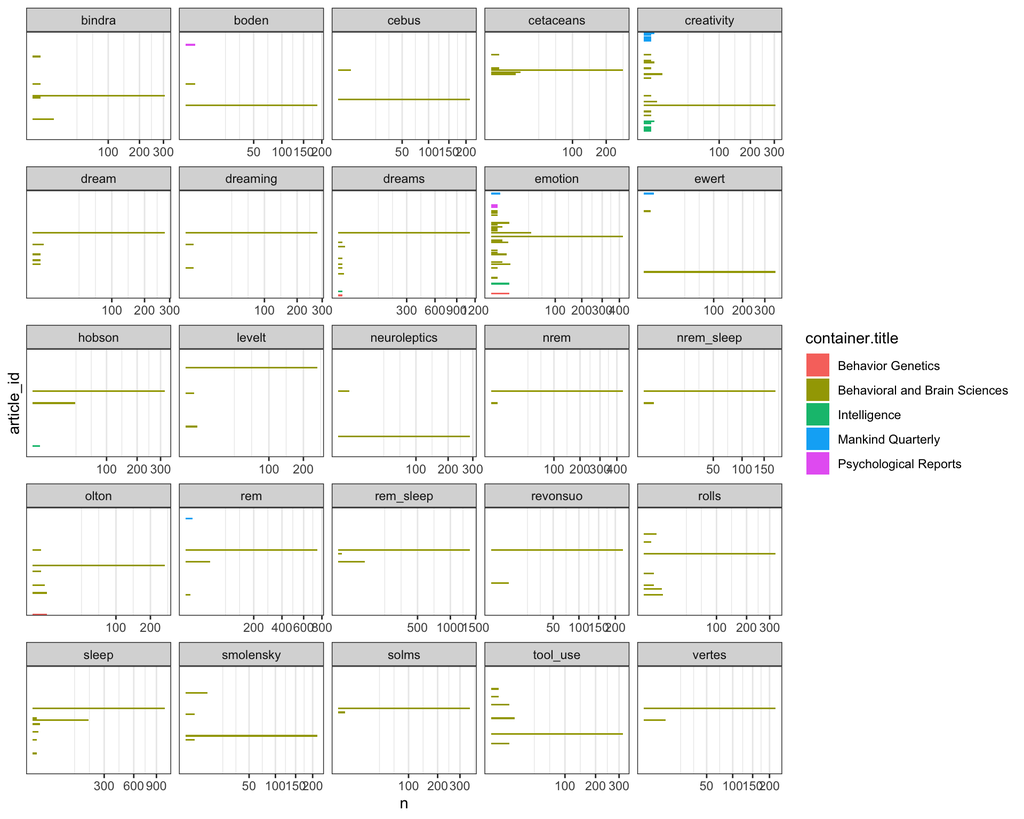

```r
terms_ndH = ndH_df |>
    pull(phrase) |>
    magrittr::extract(1:25)

subset_phr |>
    filter(phrase %in% terms_ndH) |>
    left_join(subset_meta, by = 'article_id') |>
    ggplot(aes(article_id, n, fill = container.title)) +
    geom_col() +
    facet_wrap(vars(phrase), scales = 'free_x') +
    scale_x_discrete(breaks = NULL) +
    scale_y_sqrt() +
    coord_flip() +
    theme(axis.text.y=element_blank())
```

Because the *Behavioral and Brain Science* articles (actually, collections of articles + commentaries) are so long, tokens that occur in just a few of these articles can still have large frequencies. The high-`ndH` tokens come from this weird little corner of the distribution of tokens.

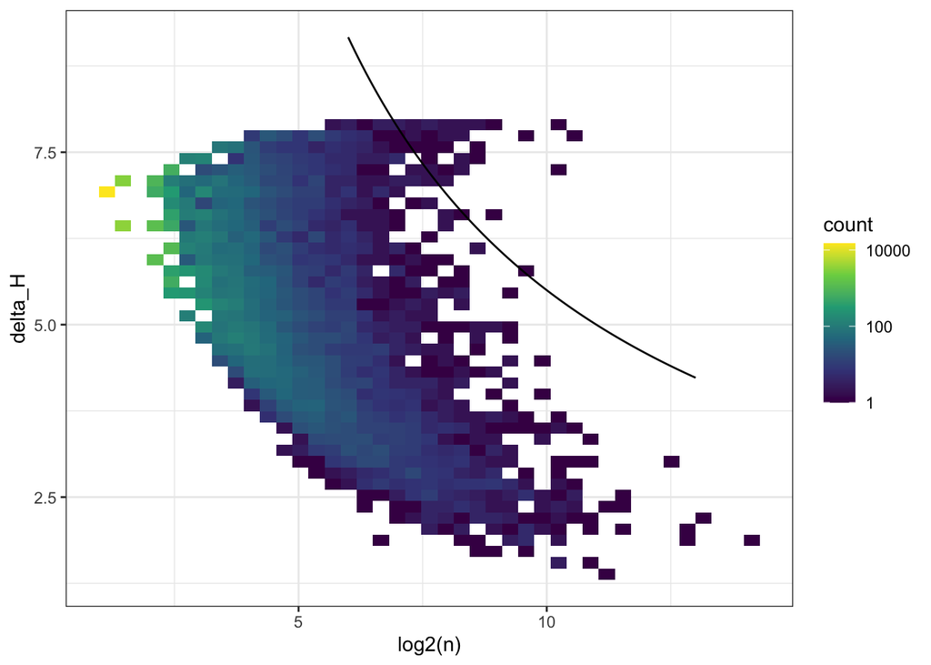

```r
ggplot(ndH_df, aes(log2(n), delta_H)) +
    geom_bin_2d(bins = 40) +
    stat_function(fun = \(x) 55/x, xlim = c(6, 13)) +
    scale_fill_viridis_c(trans = 'log10')
```

# Changing the game

Consider what the two terms in the construction of `ndH` are supposed to be doing. Frequency is supposed to pick out tokens that occur widely across the corpus, while information gain is supposed to pick out tokens that are distinctive to different documents. But, because the *Behavior and Brain Sciences* documents are so long, their distinctive tokens also end up with a high frequency. To balance this out, we can adjust information gain, penalizing tokens that come from larger documents.

We do this by changing the background conditions of the game. Suppose I pick the document not uniformly at random, but instead in proportion to length. Then you’ll gain more information from tokens that come from shorter (less likely) documents.

More formally, let $R(d) = n_d / \alpha$, where $n_d$ is the total number of tokens in document $d$ and $\alpha = \sum_d n_d$ is the total number of tokens across the entire corpus. We then calculate information gain for token $t$ using $P_t$ and KL divergence, but from $R$ instead of $Q$.
$$D_{KL}(P_t || R) = \sum_{d} P_t(d) \log \left( \frac{P_t(d)}{R(d)} \right)$$
I don’t think this one simplifies nicely, so we’ll just use the right-hand side directly in the calculation.

First we need to calculate $R(d)$.

```r
r_df = subset_phr |>
    group_by(article_id) |>
    summarize(len = sum(n)) |>
    mutate(alpha = sum(len),
           r = len/alpha)

r_df
```

```
## # A tibble: 250 × 4
##    article_id           len  alpha        r
##    <chr>              <int>  <int>    <dbl>
##  1 10.1007/bf01065449  1085 925189 0.00117
##  2 10.1007/bf01065478  1380 925189 0.00149
##  3 10.1007/bf01065562  1599 925189 0.00173
##  4 10.1007/bf01065605   349 925189 0.000377
##  5 10.1007/bf01065624  1057 925189 0.00114
##  6 10.1007/bf01065638   489 925189 0.000529
##  7 10.1007/bf01065665   790 925189 0.000854
##  8 10.1007/bf01065694   532 925189 0.000575
##  9 10.1007/bf01065819  1143 925189 0.00124
## 10 10.1007/bf01065824  2273 925189 0.00246
## # … with 240 more rows
```

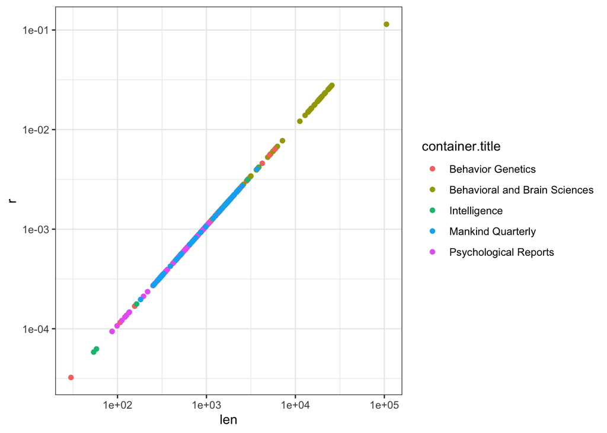

```r
r_df |>
    left_join(subset_meta, by = 'article_id') |>
    ggplot(aes(len, r, color = container.title)) +
    geom_point() +
    scale_x_log10() +
    scale_y_log10()
```

Then we calculate the divergence and, as with `ndH`, multiply by log frequency.

```r
d_df = subset_phr |>
    left_join(r_df, by = 'article_id') |>
    group_by(phrase) |>
    mutate(p = n/sum(n),
           H_term = - p * log2(p),
           d_term = p * log2(p / r)) |>
    summarize(n = sum(n),
              H = sum(H_term),
              delta_H = max_H - H,
              d = sum(d_term)) |>
    filter(H > 0) |>
    mutate(nd = log2(n)*d) |>
    arrange(desc(nd))

head(d_df, 20)
```

```
## # A tibble: 20 × 6
##    phrase                     n      H delta_H     d    nd
##    <chr>                  <int>  <dbl>   <dbl> <dbl> <dbl>
##  1 univ                     132 0.584     7.38  8.48  59.8
##  2 gpa                       98 0.287     7.68  8.45  55.9
##  3 sat                      134 0.891     7.08  7.76  54.8
##  4 money                    250 0.849     7.12  6.61  52.7
##  5 flynn_effect              89 1.39      6.58  8.09  52.4
##  6 devi                      65 0.270     7.70  8.64  52.0
##  7 srt                       57 0.346     7.62  8.72  50.9
##  8 whistle                   52 0.371     7.59  8.62  49.2
##  9 war                       87 2.12      5.84  7.57  48.8
## 10 ei                        71 0.985     6.98  7.92  48.7
## 11 india                    145 2.47      5.50  6.77  48.6
## 12 neuroleptics             290 0.0594    7.91  5.85  47.9
## 13 comorbidity               51 0.239     7.73  8.36  47.4
## 14 ee                        66 0.852     7.11  7.76  46.9
## 15 ewert                    359 0.0774    7.89  5.47  46.5
## 16 nettelbeck                66 1.45      6.52  7.62  46.0
## 17 sex_difference            64 1.69      6.28  7.63  45.8
## 18 scholastic_performance    34 0.382     7.58  8.99  45.7
## 19 larvae                    37 1.15      6.81  8.71  45.4
## 20 self_esteem               29 1.13      6.83  9.21  44.8
```

The plot of these two components doesn’t have the weird peninsula in the upper-right. Instead the highest values come from combining moderate information gain with moderate frequency, which is probably what we want.

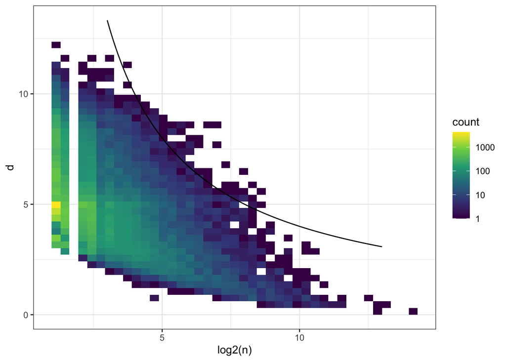

```r
ggplot(d_df, aes(log2(n), d)) +
    geom_bin_2d(bins = 40) +
    stat_function(fun = \(x) 40/x, xlim = c(3, 13)) +
    scale_fill_viridis_c(trans = 'log10')
```

We can also compare $\Delta H$ to information gain from $R$. They’re correlated; but high $\Delta H$ corresponds to a wide range of values with this new information gain calculation. Distinctive terms from large documents are nudged down, while distinctive terms from small documents are nudged up.

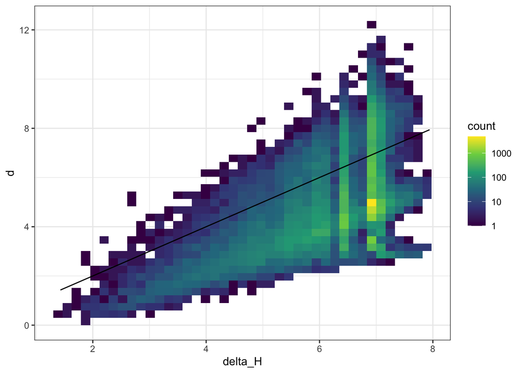

```r
ggplot(d_df, aes(delta_H, d)) +
    geom_bin_2d(bins = 40) +
    stat_function(fun = identity) +
    scale_fill_viridis_c(trans = 'log10')
```

Plotting frequencies of the top 25 terms indicates that this approach is picking out terms from across the different journals in the corpus. They also appear to correspond to different topics, rather than the excess emphasis on sleep and dreaming that we got using `ndH`.

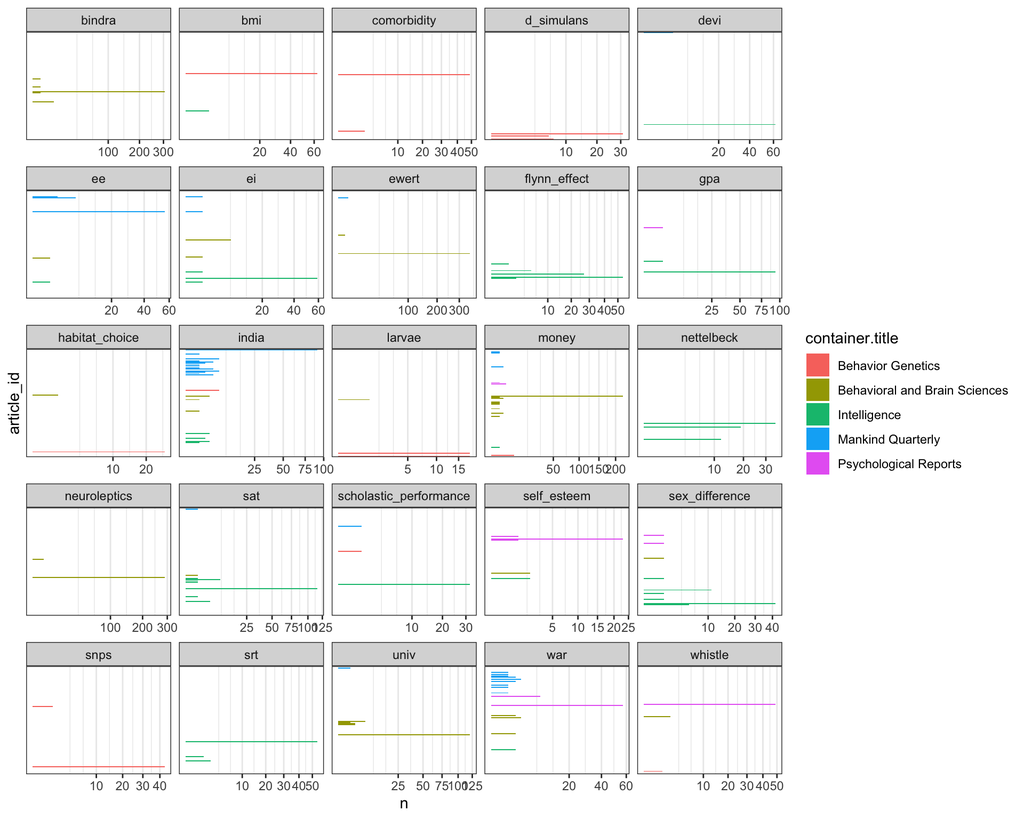

```r
terms_nd = d_df |>
    pull(phrase) |>
    magrittr::extract(1:25)

subset_phr |>
    filter(phrase %in% terms_nd) |>
    left_join(subset_meta, by = 'article_id') |>
    ggplot(aes(article_id, n, fill = container.title)) +
    geom_col() +
    facet_wrap(vars(phrase), scales = 'free_x') +
    scale_x_discrete(breaks = NULL) +
    scale_y_sqrt() +
    coord_flip() +
    theme(axis.text.y=element_blank())
```